# Bootstrap Aggregating [ Bagging ]

Tejus

13/11/2020

## Bootstrap aggregating (bagging)

**Basic idea**:

1. Resample cases and recalculate predictions
2. Average or majority vote

**Notes**:

- Similar bias
- Reduced variance
- More useful for non-linear functions

## Ozone data

```r
load("./Data/ozone.RData")
ozone <- ozone[order(ozone$ozone),]
head(ozone)
```

```
##     ozone radiation temperature wind
## 17      1         8          59  9.7
## 19      4        25          61  9.7
## 14      6        78          57 18.4
## 45      7        48          80 14.3
## 106     7        49          69 10.3
## 7       8        19          61 20.1
```

- Predicting temperature as a function of Ozone

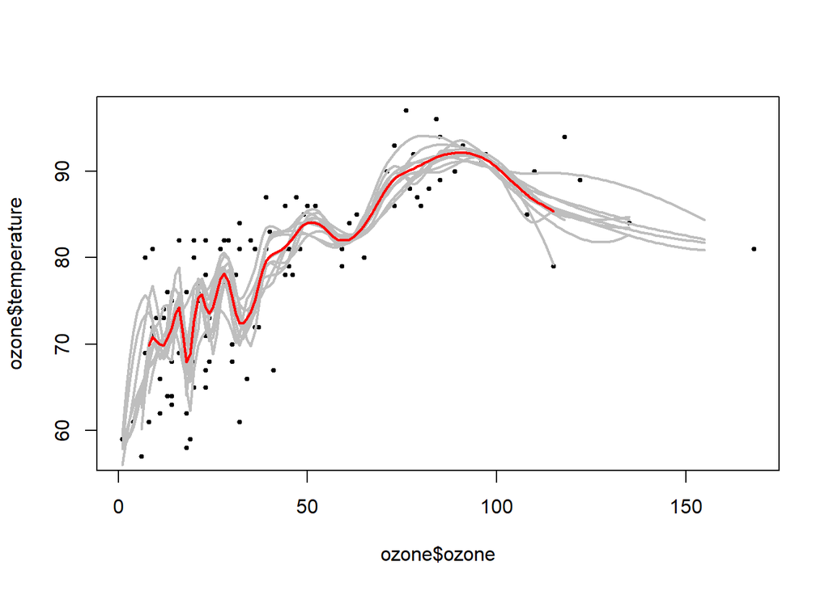

```r
ll = matrix(NA, ncol = 155, nrow = 10)
for (i in 1:nrow(ll)) {
      Resample <- sample(1:dim(ozone)[1], replace = T)
      New_Ozone <- ozone[Resample,]; New_Ozone <- New_Ozone[order(New_Ozone$ozone),]
      loess0 <- loess(temperature ~ ozone, data = New_Ozone, span = 0.2)
      ll[i,] <- predict(loess0, newdata = data.frame(ozone=1:155))
}

plot(ozone$ozone,ozone$temperature,pch=19,cex=0.5)
for(i in 1:10){lines(1:155,ll[i,],col="grey",lwd=2)}
lines(1:155,apply(ll,2,mean),col="red",lwd=2)
```

- So basically the red line is the average `Loess` curve, thus with the same data (resampled of course) we get same bias but less variance due to averaging

## Bagging in caret

- Some models perform bagging for you, in `train` function consider `method` options
  - `bagEarth`
  - `treebag`
  - `bagFDA`
- Alternatively you can bag any model you choose using the `bag` function

## Custom bagging in caret

```r
set.seed(143)
predictors = data.frame(ozone=ozone$ozone) # Predictor Df
temperature = ozone$temperature     # Y variable
treebag <- bag(predictors, temperature, B = 10,
                bagControl = bagControl(fit = ctreeBag$fit,
                                        predict = ctreeBag$pred,
                                        aggregate = ctreeBag$aggregate))
```

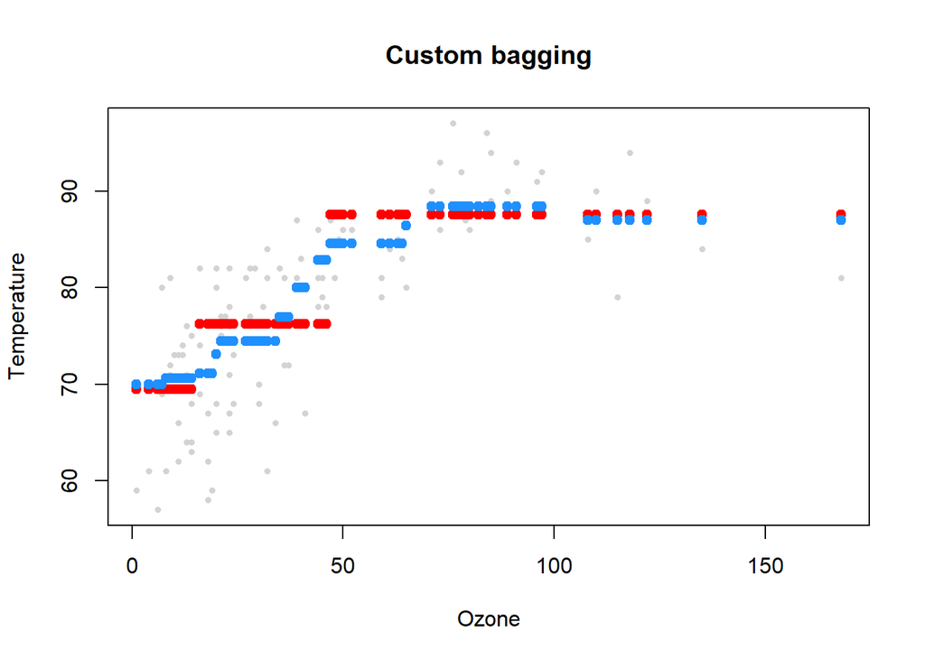

```r
# Plot to show the bagging
plot(ozone$ozone,temperature,col='lightgrey',pch=16, cex=0.6, main = "Custom bagging", xlab = "Ozone", ylab = "Temperature")
points(ozone$ozone,predict(treebag$fits[[1]]$fit,predictors),pch=19,col="red") # Default 1 fit model
points(ozone$ozone,predict(treebag,predictors),pch=19,col="dodgerblue") # Bagged fit model
```

- You can see that the slanting trend between `Temperature` variable `70 - 80` was evidently well captured by the bagged model fit (`blue`).
- `ctreeBag$fit` : A function in `caret` pckg for building a `Conditional Tree` model
- `ctreeBag$pred` : Returns the prediction for a newdata using the above `ctree` model
- `ctreeBag$aggregate` : Aggregates the models built from resampled data
- Other models can be used in the above `bag()` function also.

## Notes and further resources

**Notes**:

- Bagging is most useful for nonlinear models
- Often used with trees - an extension is random forests
- Several models use bagging in caret’s *train* function

**Further resources**:

- [Bagging](http://en.wikipedia.org/wiki/Bootstrap_aggregating)
- [Bagging and boosting](http://stat.ethz.ch/education/semesters/FS_2008/CompStat/sk-ch8.pdf)
- [Elements of Statistical Learning](http://www-stat.stanford.edu/~tibs/ElemStatLearn/)